# Fundamentals

# Functions

Functions are first-class in R: they can be passed, and defined in a scope. The return value is the last expression evaluated.

Interestingly, even `[]` is a function. Rather, `[` is. To use it we must surround it in backticks.

```r
`[`(c(5,6,7,8), 2)
```

```
## [1] 6
```

## Arguments

```r
formals(rnorm)
```

```
## $n
##
##
## $mean
## [1] 0
##
## $sd
## [1] 1
```

An interesting look at how `formals` and `alist` work

```r
f <- function() x
formals(f) <- al <- alist(x =, y = NULL, ... =)
print(f)
```

```
## function (x, y = NULL, ...)
## x
```

```r
print(al)
```

[output not shown]

The following demonstrates some things about argument order.

```r
mydata <- rnorm(100)
sd(mydata)      # mydata is passed as the first argument, the rest are default
sd(x = mydata)  # equivalent to above
sd(x = mydata, na.rm = FALSE)
sd(na.rm = FALSE, x = mydata) # fine, but not recommended to change around order
sd(na.rm = FALSE, mydata)     # since mydata is unnamed, it will be assigned to the first expected argument, x
```

When an argument is matched by name, it is “taken out” of the list, and following arguments will be matched in order.

## Lazy Evaluation

Here, `c` has a default value, but `b` doesn’t, but `b` isn’t used so we don’t really care.

```r
f1 <- function(a, b, c = TRUE) {
  a^2
}

f2 <- function(a,b) {
  print(a)
  print(b)
}
```

Calling `f2(45)` will print 45, THEN error, because 45 will match for `a`, and `b` will be unmatched when it is called.

## …

`...` argument indicates a variable number of arguments that are usually passed on to other functions. Here we extend `plot` and accept any arguments that it would take.

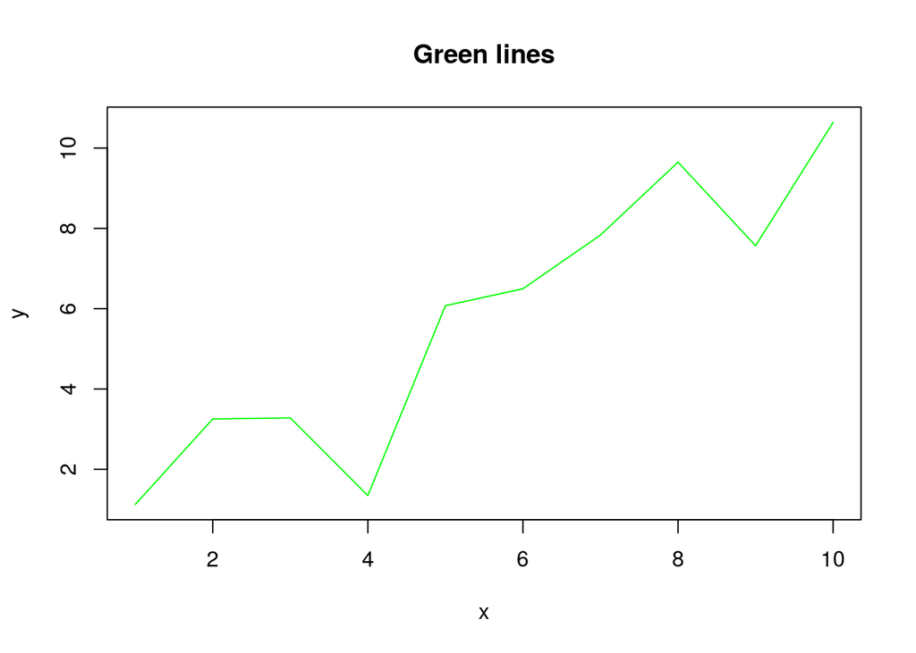

```r
myplot <- function(x, y, type="l", ... ) {
  plot(x, y, type = type, col="green", main="Green lines", ... )
}
myplot(1:10, 1:10+rnorm(10))
```

`paste` doesn’t know how many objects it will be pasting, so … is the first argument

```r
args(paste)
```

```
## function (..., sep = " ", collapse = NULL)
## NULL
```

**NOTE**: Arguments that appear after the … must be explicitly named (and cannot be partially matched).

dotdotdot example .R

## Scope

## anonymous/closure/lambda

```r
x <- list(a = matrix(1:4, 2,2), b= matrix(1:6, 3,2))
lapply(x, function(y) y[,1])
```

```
## $a
## [1] 1 2
##
## $b
## [1] 1 2 3
```

```r
f1 <- function(x) ifelse(x >= 0, sqrt(x), NA)
f1(2)
```

```
## [1] 1.414214
```

```r
f1(-1)
```

```
## [1] NA
```

> A closure has three components, its formals (its argument list), its body (expr in the ‘Usage’ section) and its environment which provides the enclosure of the evaluation frame when the closure is used.

TODO: benchmark/profiling section